# Asks

MYC

10/27/2021

Loading all the default settings and preliminary programs.

List of asks:

- A vs B,
- CDC vs NTP
- NTP 300 vs NTP 1000

Path to Processed Data and loading of cleaned data

```r
data_location <- here::here("data","processed_data","P2-20211029.rds")
data<- readRDS(data_location)
glimpse(data)
```

```
## Rows: 453
## Columns: 15
## $ Phase       <fct> 2, 2, 2, 2, 2, 2, 2, 2, 2, 2, 2, 2, 2, 2, 2, 2, 2, 2, 2, 2~
## $ PCR         <chr> "9/30/2021", "9/30/2021", "9/30/2021", "9/30/2021", "9/30/~
## $ RH          <dbl> 41.2, 41.2, 41.2, 41.2, 41.2, 41.2, 41.2, 41.2, 41.2, 41.2~
## $ TEMP        <dbl> 25.7, 25.7, 25.7, 25.7, 25.7, 25.7, 25.7, 25.7, 25.7, 25.7~
## $ Plate       <fct> 1, 1, 1, 1, 1, 1, 1, 1, 1, 1, 1, 1, 1, 1, 1, 1, 1, 1, 1, 1~
## $ Well        <chr> "A1", "A3", "A5", "A6", "A7", "A8", "A10", "A12", "B3", "B~
## $ Method      <fct> PCR, CDC, CDC, CDC, CDC, CDC, CDC, PCR, NTP, NTP, NTP, NTP~
## $ Tool        <fct> PCR.CTRL, NEG.CTRL, SD, SD, SD, SD, POS.CTRL, PCR.POS, NEG~
## $ Input       <dbl> NA, 300, 300, 300, 300, 300, 300, NA, 300, 300, 300, 300, ~
## $ Dilution    <dbl> NA, NA, -4, -3, -2, -1, -1, NA, NA, -4, -3, -2, -1, -1, -1~
## $ Copies      <chr> "", "", "840", "8,400", "84,000", "840,000", "", "", "", "~
## $ Sample.Name <chr> "NTC N1", "NEG.CTRL-CDC0300 N1", "SD-4-CDC0300 N1", "SD-3-~
## $ Detector    <fct> N1 Probe, N1 Probe, N1 Probe, N1 Probe, N1 Probe, N1 Probe~
## $ Task        <chr> "Unknown", "Unknown", "Unknown", "Unknown", "Unknown", "Un~
## $ Ct          <dbl> NA, NA, 26.7697, 23.2780, 25.0061, 20.8932, 25.7424, 19.62~
```

```r
data%>%
  group_by(Detector, Method, Tool, Input)%>%
  filter(Method!="PCR")%>%
  summarize(n=n(),
            Ct=mean(Ct))%>%
  mutate(tools=(n/2))
```

```
## # A tibble: 56 x 7
## # Groups:   Detector, Method, Tool [20]
##    Detector Method Tool     Input     n    Ct tools
##    <fct>    <fct>  <fct>    <dbl> <int> <dbl> <dbl>
##  1 N1 Probe CDC    A          300    17  28.6   8.5
##  2 N1 Probe CDC    B          300    17  NA     8.5
##  3 N1 Probe CDC    NEG.CTRL   300     3  NA     1.5
##  4 N1 Probe CDC    POS.CTRL   300     3  26.3   1.5
##  5 N1 Probe CDC    SD         300    16  22.6   8
##  6 N1 Probe NTP    A          300    18  28.2   9
##  7 N1 Probe NTP    A         1000    18  27.0   9
##  8 N1 Probe NTP    A         6700     2  27.0   1
##  9 N1 Probe NTP    A         6800     4  26.1   2
## 10 N1 Probe NTP    A         6900    10  25.1   5
## # ... with 46 more rows
```

# A vs B

Tools are used to sample different concntrations of seeded virus. A recovered from -1 inoculated coupon area. B recovered from -3 inoculated coupon area.

```r
data%>%
  filter(Tool%in% c("A", "B"))%>%
  count(Method)
```

```
##   Method   n
## 1    CDC  70
## 2    NTP 216
```

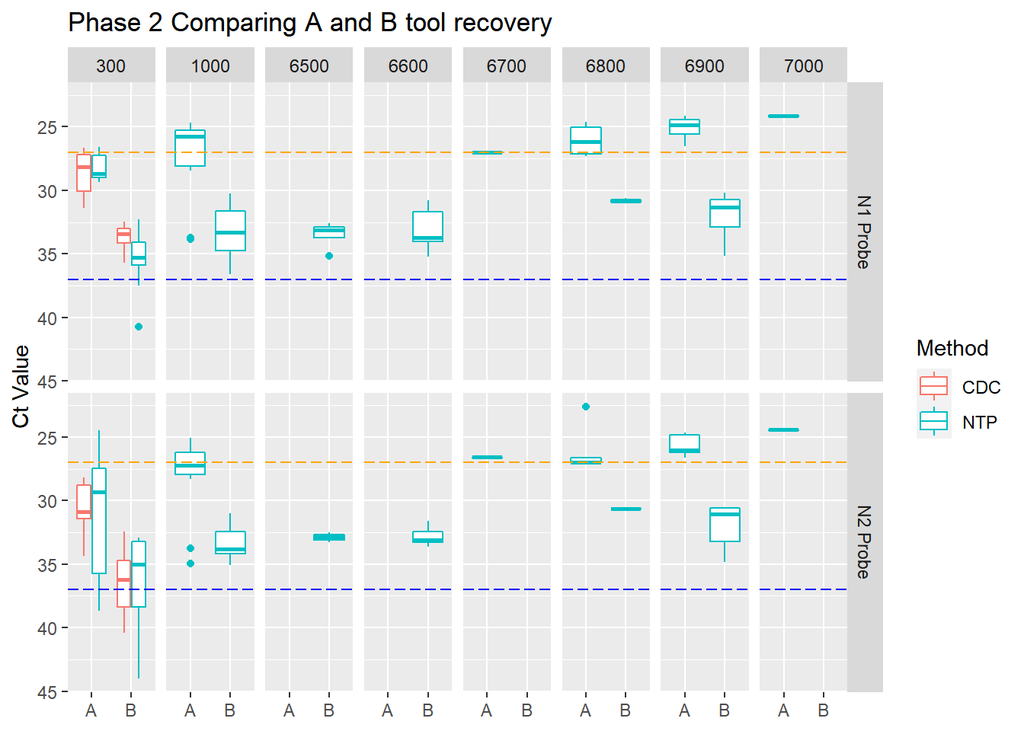

```r
AsksP2P1<-data%>%
  filter(Tool%in% c("A", "B"), Input!="6400")%>%
  ggplot(aes(x=Tool, y= Ct))+
  geom_boxplot(aes(color=Method))+
  geom_hline(yintercept=27, linetype="longdash", color = "orange")+ #CDC confirmed threshold
  geom_hline(yintercept=37, linetype="longdash", color = "blue")+ #General confirmed threshold
  facet_grid(Detector~Input)+
  scale_y_reverse()+
  labs(y="Ct Value",
       x=NULL,
       title="Phase 2 Comparing A and B tool recovery")

print(AsksP2P1)
```

```r
#save figure
figure_file = here("results","ASK-P2P1-Tools.png")
ggsave(filename = figure_file, plot=AsksP2P1)
```

# CDC vs NTP

Compare the different extraction methods Serial Dilutions

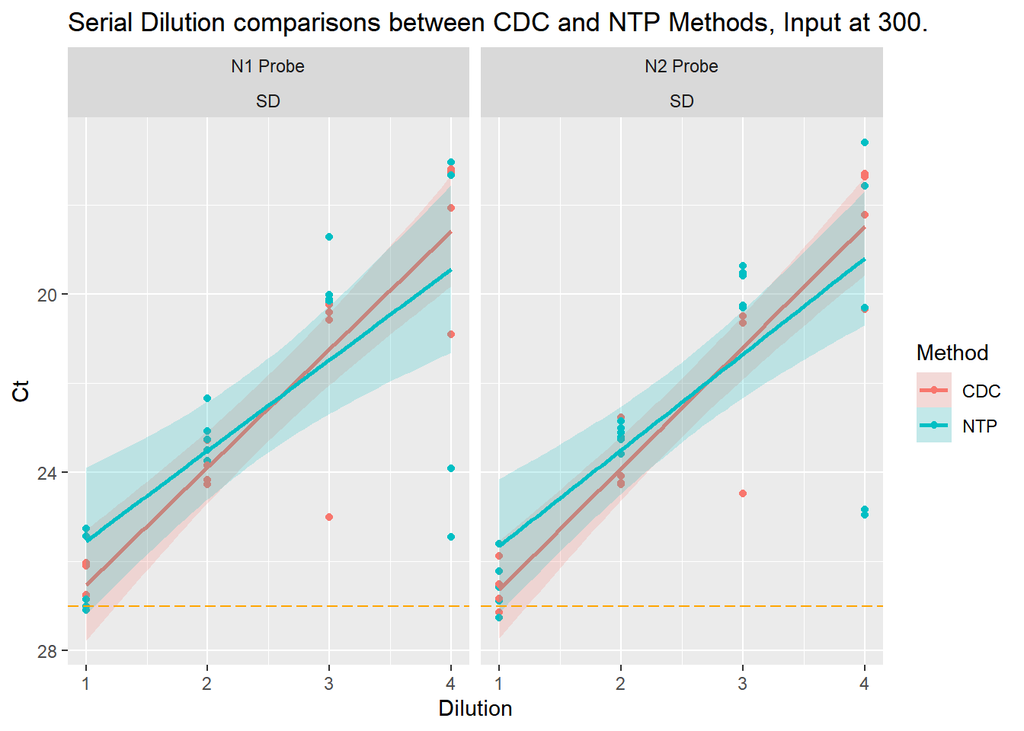

```r
AsksP2P2<-data%>%
  mutate(Dilution=as.numeric(as.factor(Dilution)))%>%
  filter(Tool=="SD", Input=="300")%>%
  ggplot(aes(x=Dilution, y=Ct, color=Method))+
  scale_y_reverse()+
  geom_point()+
  geom_smooth(aes(fill=Method),method=lm, alpha=0.20, fullrange=TRUE)+
  geom_hline(yintercept=27, linetype="longdash", color = "orange")+ #CDC confirmed threshold
#  geom_hline(yintercept=37, linetype="longdash", color = "blue")+ #General confirmed threshold
  facet_wrap(Detector~Tool)+
  labs(title = "Serial Dilution comparisons between CDC and NTP Methods, Input at 300.")

print(AsksP2P2)
```

```r
#save figure
figure_file = here("results","ASK-P2P2-Methods.png")
ggsave(filename = figure_file, plot=AsksP2P2)
```

Serial dilution data between CDC and NTP. Noting that all SD are in the confirmed realm of under 27 Ct Value CDC method is better than NTP at -1 concentration of the SD. the -2 shows little difference between method recovery Ct values. NTP appears to remain better than CDC at -3 and -4 levels. Accounting for the SE looks like both methods are the same until the -2 dilution. Might be significant difference at the -4 dilution.

Compare between extraction methods at input 300

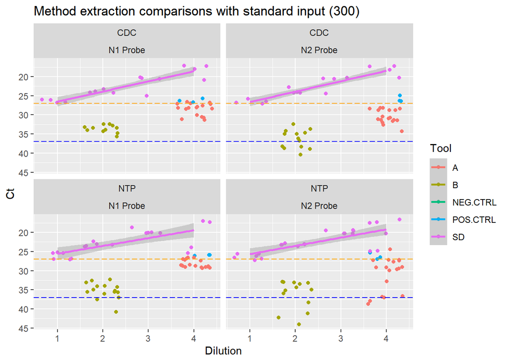

```r
AsksP2P3<- data%>%
  mutate(Dilution=as.numeric(as.factor(Dilution)))%>%
  filter(Input=="300")%>%
  ggplot(aes(x=Dilution, y=Ct, color=Tool))+
  scale_y_reverse()+
  geom_jitter()+
  geom_smooth(method=lm)+
  geom_hline(yintercept=27, linetype="longdash", color = "orange")+ #CDC confirmed threshold
  geom_hline(yintercept=37, linetype="longdash", color = "blue")+ #General confirmed threshold
  facet_wrap(Method~Detector)+
  labs(title="Method extraction comparisons with standard input (300)")

print(AsksP2P3)
```

```r
#save figure
figure_file = here("results","ASK-P2P3-Methods0300.png")
ggsave(filename = figure_file, plot=AsksP2P3)
```

Compare between extraction methods with additional inputs

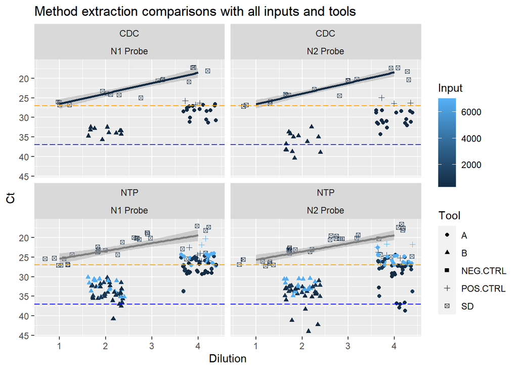

```r
AsksP2P4<-data%>%
  mutate(Dilution=as.numeric(as.factor(Dilution)))%>%
  filter(Input!="CTRL")%>%
  ggplot(aes(x=Dilution, y=Ct, shape=Tool, color=Input))+
  scale_y_reverse()+
  geom_jitter()+
  geom_smooth(method=lm)+
  geom_hline(yintercept=27, linetype="longdash", color = "orange")+ #CDC confirmed threshold
  geom_hline(yintercept=37, linetype="longdash", color = "blue")+ #General confirmed threshold
  facet_wrap(Method~Detector)+
  labs(title="Method extraction comparisons with all inputs and tools")

print(AsksP2P4)
```

```r
#save figure
figure_file = here("results","ASK-P2P4-MethodsALL.png")
ggsave(filename = figure_file, plot=AsksP2P4)
```

# NTP Input variations

Serial Dilution

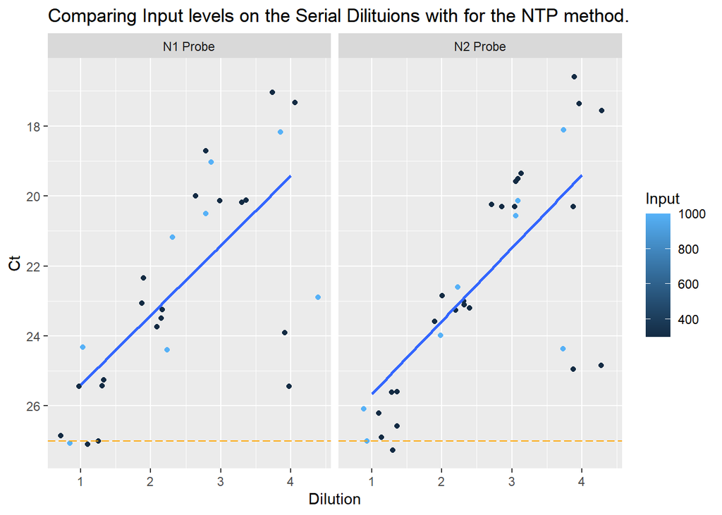

```r
AsksP2P5<-data%>%
  mutate(Dilution=as.numeric(as.factor(Dilution)))%>%
  filter(Method=="NTP", Tool=="SD", Input!="CTRL", Input!="6800")%>%
  ggplot(aes(x=Dilution, y=Ct, color=Input))+
  scale_y_reverse()+
  geom_jitter()+
  geom_smooth(method=lm, se=FALSE, fullrange=TRUE)+
  geom_hline(yintercept=27, linetype="longdash", color = "orange")+ #CDC confirmed threshold
  facet_wrap(.~Detector)+
  labs(title="Comparing Input levels on the Serial Dilituions with for the NTP method.")

print(AsksP2P5)
```

```r
#save figure
figure_file = here("results","ASK-P2P5-NTP-SD.png")
ggsave(filename = figure_file, plot=AsksP2P5)
```

If we could determine how many copies are in the -3 dilution we may be able to better estimate the capacity of the particles.

NTP

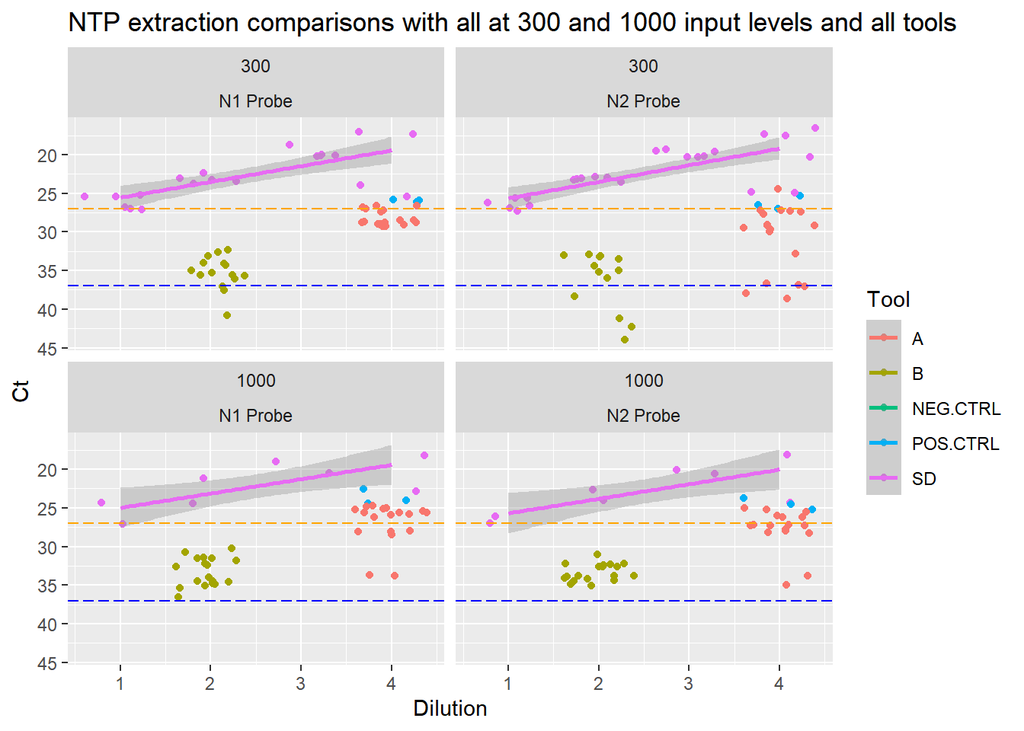

```r
AsksP2P6<-data%>%
  mutate(Dilution=as.numeric(as.factor(Dilution)))%>%
  filter(Method=="NTP", Input<=6000)%>%
  ggplot(aes(x=Dilution, y=Ct, color=Tool))+
  scale_y_reverse()+
  geom_jitter()+
  geom_smooth(method=glm, fullrange=TRUE)+
  geom_hline(yintercept=27, linetype="longdash", color = "orange")+ #CDC confirmed threshold
  geom_hline(yintercept=37, linetype="longdash", color = "blue")+ #General confirmed threshold
  facet_wrap(Input~Detector)+
  labs(title="NTP extraction comparisons with all at 300 and 1000 input levels and all tools")
print(AsksP2P6)
```

```r
#save figure
figure_file = here("results","ASK-P2P6-NTP.png")
ggsave(filename = figure_file, plot=AsksP2P6)
```

NTP NTP extraciton comparisons with eluent input levels and all tools

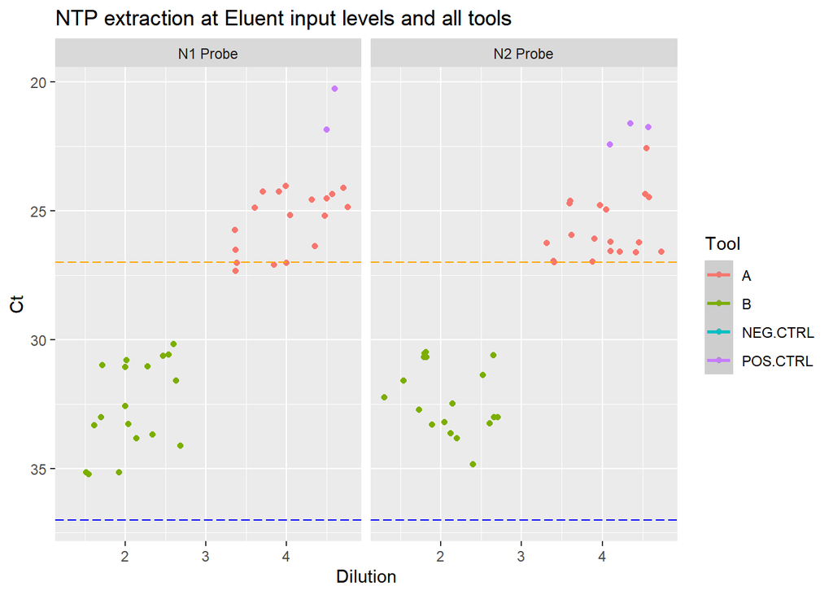

```r
data%>%
  mutate(Dilution=as.numeric(as.factor(Dilution)))%>%
  filter(Method=="NTP", Input!="CTRL", Input>=6000)%>%
  ggplot(aes(x=Dilution, y=Ct, color=Tool))+
  geom_jitter()+
  scale_y_reverse()+
  geom_smooth(method=glm, fullrange=TRUE)+
  geom_hline(yintercept=27, linetype="longdash", color = "orange")+ #CDC confirmed threshold
  geom_hline(yintercept=37, linetype="longdash", color = "blue")+ #General confirmed threshold
  facet_wrap(.~Detector)+
  labs(title="NTP extraction at Eluent input levels and all tools")
```

Negatives show no detection. Positive controls are at -1 and have smaller Ct value than the A tools which recovered -1 inoculations. Gold line represents the threshold of 27

```r
data%>%
  filter(Input>=6000, Input!="CTRL")
```

```
##    Phase        PCR    RH  TEMP Plate Well Method     Tool Input Dilution
## 1      2  9/30/2021 41.20 25.70     2   B3    NTP NEG.CTRL  6800       NA
## 2      2  9/30/2021 41.20 25.70     2  B10    NTP POS.CTRL  6800       -1
## 3      2  9/30/2021 41.20 25.70     2   D1    NTP        A  6800       -1
## 4      2  9/30/2021 41.20 25.70     2   D2    NTP        A  6800       -1
## 5      2  9/30/2021 41.20 25.70     2   D3    NTP        A  6900       -1
## 6      2  9/30/2021 41.20 25.70     2   D4    NTP        A  6900       -1
## 7      2  9/30/2021 41.20 25.70     2   D5    NTP        A  6900       -1
## 8      2  9/30/2021 41.20 25.70     2   D6    NTP        A  6900       -1
## 9      2  9/30/2021 41.20 25.70     2   D7    NTP        B  6600       -3
## 10     2  9/30/2021 41.20 25.70     2   D8    NTP        B  6600       -3
## 11     2  9/30/2021 41.20 25.70     2   D9    NTP        B  6500       -3
## 12     2  9/30/2021 41.20 25.70     2  D10    NTP        B  6500       -3
## 13     2  9/30/2021 41.20 25.70     2  D11    NTP        B  6600       -3
## 14     2  9/30/2021 41.20 25.70     2  D12    NTP        B  6600       -3
```

[output cut: 157 more lines]